# (Effects of some variables on Loan Status)

## by (Maha Ahmed)

## Investigation Overview

> In this investigation, I wanted to look at some variables of loans that could be used to predict their Status whether Completed ,current , chargedoff ,e. The main focus was on the ListingCategory ,IncomeRange, loan term , Employment Status , original loan amount, BorrowerAPR, borrowerRate and stated monthly income.

## Dataset Overview

> The dataset consisted of Loan Status and attributes of 113,937 loans. The attributes included ListingCategory ,IncomeRange, loan term , Employment Status , original loan amount , and much more with 81 variables. 2280 data points were removed from the analysis due to missing values ,25 values removed from BorrowerAPR and 2255 from EmploymentStatus .

## (Distribution of LoanStatus)

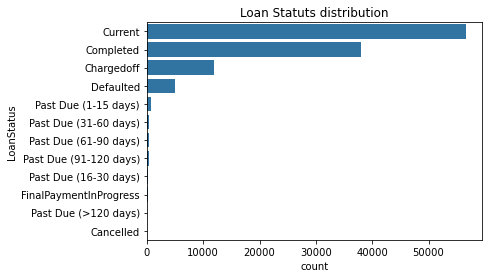

## (Distribution of ListingCategory)

> Interestingly, it looks like 51.2% of the borrowers asking for loan to Dept consolidation and 14.9% are not available to know .

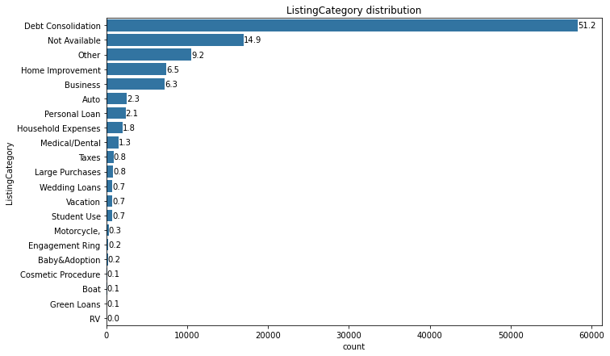

## (Distribution of BorrowerAPR)

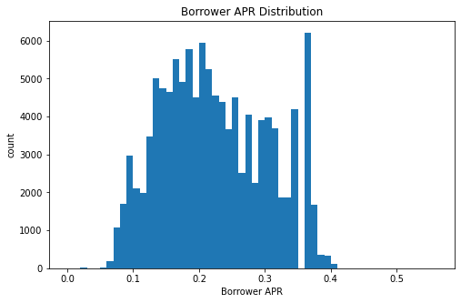

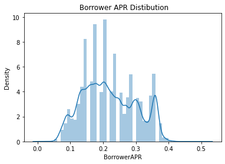

## Distribution of LoanOriginalAmount

> The box plot of the original amount of loans suggested that the distribution is right-skewed with the center observed at approximately 7,000 However, the histogram did not show a gradual decrease in the observed frequency with increasing amount of loans. For instance, the observed frequencies for the fifth and the eighth bins were larger than two times the frequencies of the fourth and seventh bins

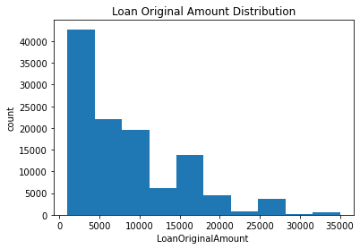

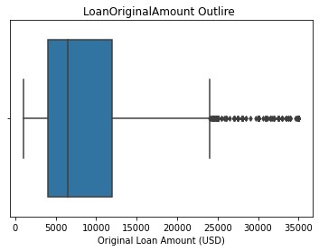

## (LoanStauts vs BorrowerAPR)

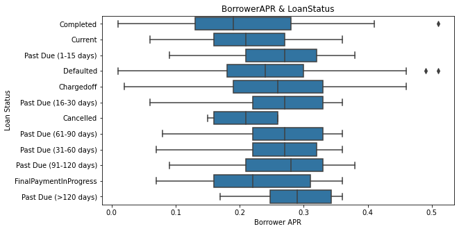

## (LoanStatus vs. term)

> according to the countplot 34800 of borrowers with three year Term have almost Completed the Loans . and 35400 of borrowers with Three years term was still paying the loan .

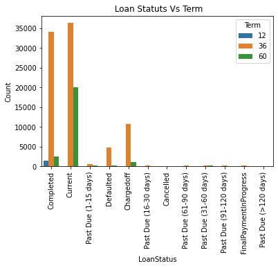

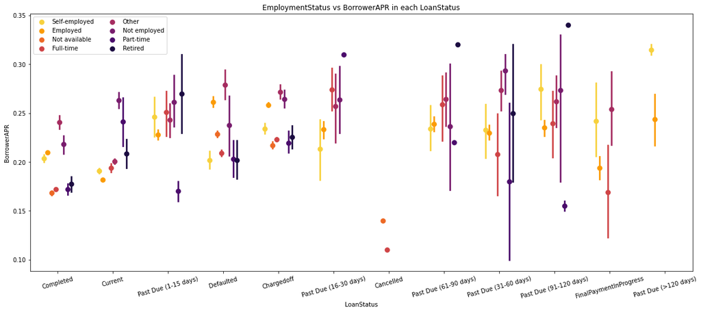

## (LoanStatus vs LoanOriginalAmount, BorrowerRate,BorrowerAPR and StatedMonthlyIncome)

> Based on the plot as was showed previously the negative relationship between LoanStauts,BorrowerRate , LoanOriginalAmont And BorrowerRate and no significant relationship between StatedMonthlyIncome

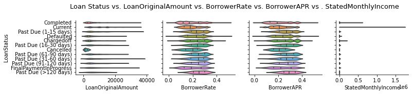